# Mini-cursos: Introdução ao R - Mapeamento Genético - Sequenciamento de RNA e Expressão Diferencial

Para todas as práticas é necessário fazer o download da pasta "Arquivos_Workshop-master" no menu localizado no canto direito superior desta página.

No menu você também encontrará as apresentações teóricas e outras informações.

## Introdução ao r {prática 3}

27 Jul 2015

Nesta prática trabalharemos com:

- Instalação de pacotes;
- Utilização do pacote *maptools*

Para instalar um pacote no R é apenas necessário saber o nome dele e seguir com os comandos:

```r
install.packages("maptools") #Este comando é para instalar o pacote
library(maptools) #Este comando vai ativar o pacote, ele é necessario toda vez que você for utlizar este pacote
```

Este pacote tem ferramentas para fazer a leitura e manipular dados geográficos contidos em arquivos denominados *shapefiles*. Você pode obter mais informações sobre o pacote [aqui](https://cran.r-project.org/web/packages/maptools/index.html), onde também poderá fazer download do seu manual.  
Nesta prática vamos usar o *maptools* para inserir pontos de coordenadas em um mapa. Um exemplo mais complexo pode ser encontrado no blog [R-Bloggers](http://www.r-bloggers.com/create-maps-with-maptools-r-package/)  
Para isso precisaremos de alguns arquivos para montar o nosso mapa. Se você ainda não fez o download da pasta [“Arquivos_workshop”](https://github.com/Cristianetaniguti/Arquivos_workshop/archive/master.zip) faça agora.  
Utilizaremos os arquivos da pasta **“R_intro”** que contém os *shapefiles* e o arquivo com as coordenadas. Coloque todos os arquivos no seu diretório de trabalho, ou mude para onde eles estiverem.

```r
#Inicialmente indicamos o mapa que queremos usar
BRASIL.shp <- readShapeSpatial("regioes_2010.shp", proj4string=CRS("+proj=longlat"))

#Depois carregamos a tabela com as coordenadas
pontos<- read.table("coordenadas_2015confirmados.csv", sep=",", dec=".", header=TRUE)
```

Notem que utilizamos a função *read.table* com os argumentos dizendo que nosso arquivo tem as colunas separadas por vírgula, os decimais com ponto e que temos um cabeçalho. Uma forma de conferir isso é abrir o arquivo num bloco de notas antes.  
Já estamos nos finalmentes:

```r
# Gerar o mapa contido no arquivo shapefile
# Cores e espessura de linha podem ser personalizadas.
plot(BRASIL.shp, lwd=.5, col= colors()[204])

# Plotar os pontos contidos na planilha
# A o formato, cor e espessura dos pontos também podem ser alterados.
points(pontos$Longitude, pontos$Latitude, pch=16, col=colors()[259], cex=1.0)

# Se desejar é possível adicionar um título ao mapa.
title("Alunos do IX Workshop de Genética - ESALQ /2015",
      sub="Locais indicados no formulário de inscrição")
```

Pronto! O resultado deve ter ficado semelhante ao da imagem a seguir.

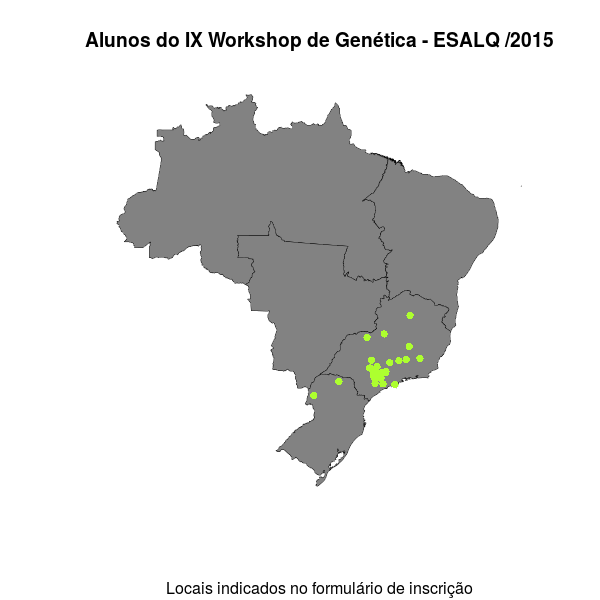

Gostariamos de agradecer ao Ms. Lucas Mitsuo Taniguti por ter elaborado esta prática. Você pode verificar outros posts dele e do grupo de Genética e Microorganismos de Plantas (ESALQ-USP) [aqui](http://amos.esalq.usp.br/blog/?page_id=248)  
Acompanhe também os posts na página do nosso Laboratório de Genética Estatística (ESALQ-USP) por [aqui](http://augusto-garcia.github.io/statgen-esalq/)

*Este material faz parte do mini-curso de “Introdução ao R” do IX Workshop de Férias em Genética e Melhoramento de Plantas organizado pelos alunos de pós-graduação do programa de Genética e Melhoramento de Plantas da ESALQ-USP.*